# lnR_metabolomics: univariate analysis

Ming Yang

Compiled: October 10, 2021

# Data description and visualization

**60 samples in total**

- 5 genotypes: wt, wt/353, 74/211, 211/19, 19/74
- 2 ages: 15d, 30d
- 3 batches: 1, 2, 3

2 replicates per genotype per age per batch

**I combine 5 genotypes into 3 modes**

- wt: wildtype
- mode.1: 74/211, 211/19, 19/74. These genotypes may extend lifespan by reducing costs of reproduction.
- mode.2: This genotype may provide ‘longevity assurance’

Plot two metabolite’s abundance among different modes and ages as examples

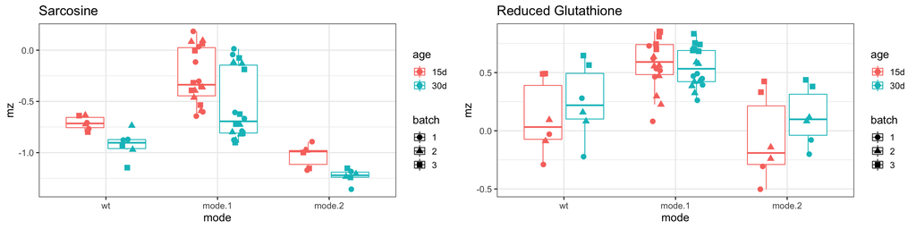

```r
dat=readRDS('./mz.filter.dat.rds')
df.mat=dat$edata;
pheno=dat$pheno

## log transform
#summary(as.numeric(unlist(df.mat))) #no zero, log directly
df.mat.log=log(df.mat)

## normalize by sample
df.scaled=scale(df.mat.log,center=T,scale=T)
#apply(df.scaled,2,mean) #confirm
#apply(df.scaled,2,sd) #confirm

## genotype explain
#wt is wildtype
#wt/353 is the ‘Mode 2’, no trade-off
#the other three are the 'Mode 1', extend lifespan by reducing costs of reproduction.
pheno$mode='mode.1';
pheno[pheno$genotype=='wt/353',]$mode='mode.2'
pheno[pheno$genotype=='wt',]$mode='wt'
#table(pheno$mode)
#mode.1 mode.2     wt
#36     12     12

# select two metabolites
pick.mz=c('Sarcosine','Reduced Glutathione');
df.tmp=df.scaled[pick.mz,]
plots=lapply(1:nrow(df.tmp),function(i){
    mz=df.tmp[i,]
    mz.name=rownames(df.tmp)[i]
    tmp=data.frame(mz=as.numeric(mz),age=factor(pheno$age),mode=factor(pheno$mode),batch=factor(pheno$batch));
    tmp$group=factor(paste(tmp$mode,tmp$age))
    tmp$mode=factor(tmp$mode,levels=c('wt','mode.1','mode.2'))
    ggplot(tmp,aes(x=mode,y=mz,col=age,group=group,shape=batch))+
      geom_boxplot(outlier.shape = NA) +
      geom_jitter(size=3,position = position_jitterdodge())+
      theme_bw(base_size = 14)+ggtitle(mz.name)
  })
  do.call(grid.arrange,c(plots,ncol=2))
```

Look at these two plots, it appears that both `mode` and `age` affect `Sarcosine` while only `mode` affects `Reduced Glutathione`.

In the following analysis, I performed linear regression analysis on each metabolite to identify those metabolites with a significant `age` or `mode` or `age:mode interaction` effect.

# linear regression on each metabolite with batch effect removed using `combat` function from `sva` R package

- I performed linear regression on each metabolite using: **metabolite.abundance ~ age + mode + age:mode + error**
- then used `Anova` to test the significance of each term, i.e., age, mode, age:mode interaction term.
- The significance, or the P value, of each term for each metabolite was adjusted using `p.adjust` function in R with the `BH` method, referred to as `p.adj`.

```r
df.res=readRDS('mz.filter.combat.rds')
### use genotype and age as predictor
out=lapply(1:nrow(df.res),function(i){
  mz=df.res[i,]
  mz.name=rownames(df.res)[i] # fit model using df.res with age and mode as predictor, including interaction term
  tmp=data.frame(mz=as.numeric(mz),age=factor(pheno$age),mode=factor(pheno$mode));
  tmp$mode=factor(tmp$mode,levels=c('wt','mode.1','mode.2'))
  x=lm(mz~age*mode,tmp )
  x
})

# use Anova to get p values for each factor of each mz
#Anova(out[[1]])
sig.out=lapply(out,function(x){ #make a table
  x1=Anova(x)
  #x1=summary(x) #this gives you coef, coef.p.value for each term
  pvalue=x1$`Pr(>F)`
  #terms=rownames(x1)
  pvalue
})

df.sig.out=Reduce(`rbind`,sig.out)
x1=Anova(out[[1]])
colnames(df.sig.out)=rownames(x1)
rownames(df.sig.out)=rownames(df.res)
df.sig.out=df.sig.out[,-4] #remove Residuals column
df.sig.out.adj=data.frame(matrix(p.adjust(df.sig.out,method = 'BH'),ncol=ncol(df.sig.out)))
rownames(df.sig.out.adj)=rownames(df.sig.out)
colnames(df.sig.out.adj)=colnames(df.sig.out)
```

After regression, for each metabolite, there are 3 p.adj values, one for a predictor term:

```r
df.sig.out.adj[c(rownames(df.sig.out.adj)[1:3],pick.mz),]
```

|  | age | mode | age:mode |
| --- | --- | --- | --- |
| Ethanolamine | 7.404162e-01 | 5.998519e-07 | 0.320729309 |
| Glycine | 2.640243e-06 | 1.014266e-02 | 0.004234486 |
| betaAlanine | 4.264479e-04 | 7.183473e-03 | 0.034312130 |
| Sarcosine | 7.310947e-04 | 1.170931e-10 | 0.859936102 |
| Reduced Glutathione | 2.641284e-01 | 2.164340e-17 | 0.024781467 |

Have a look at the P.adj distributions for these three temrs:

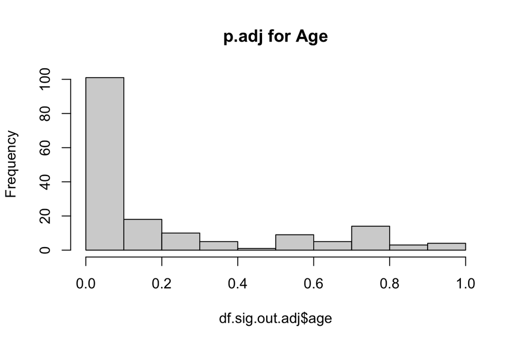

```r
hist(df.sig.out.adj$age,main='p.adj for Age')
```

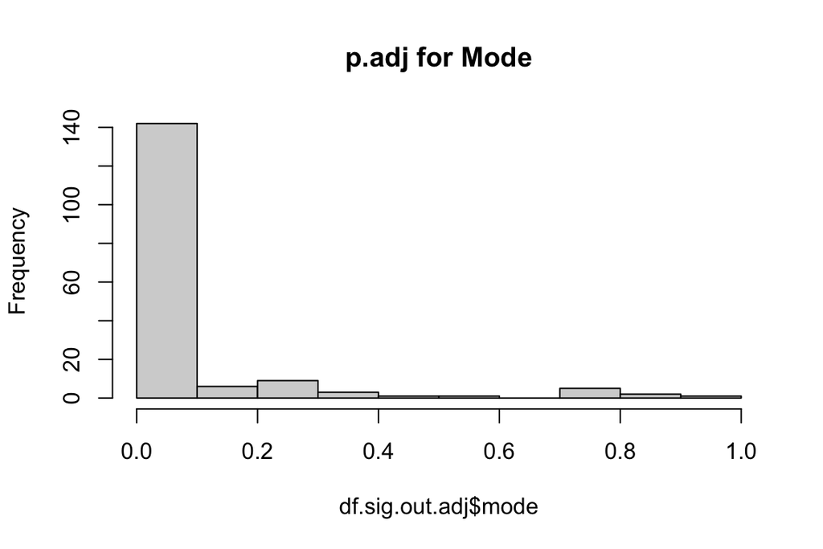

```r
hist(df.sig.out.adj$mode,main='p.adj for Mode')
```

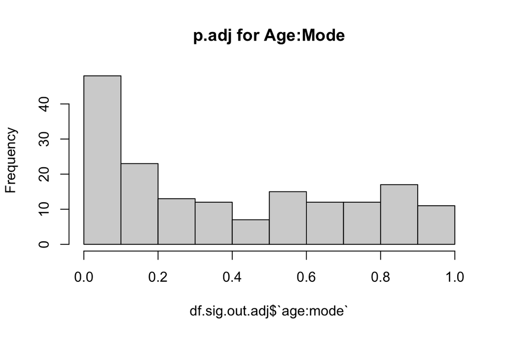

```r
hist(df.sig.out.adj$`age:mode`,main='p.adj for Age:Mode')
```

For these 170 metabolites, after fitting this linear model, the number of metabolites that were significantly affected by terms at a p.adj<0.05 cutoff:

```r
#nrow(df.sig.out.adj) #170
apply(df.sig.out.adj,2,function(i){sum(i<0.05)})
```

```
##      age     mode age:mode
##       91      136       33
```

```r
#age     mode age:mode
#91      136       33
#rownames(df.sig.out.adj[df.sig.out.adj$mode<0.05,])
#df.sig.out.adj['Sarcosine',]
```

# linear mixed regression on each metabolite using batch as a random effect

- I performed linear mixed regression on each metabolite using `lmer` function from the `lme4` R package:

**lmer(metabolite.abundance ~ mode + age + mode:age + (1|batch))**

- then used `Anova` to test the significance of each term, i.e., age, mode, age:mode interaction term.
- The significance, or the P value, of each term for each metabolite was adjusted using `p.adjust` function in R with the `BH` method, referred to as `p.adj`.

```r
## use batch as random effect, fit linear mixed model
#head(df.scaled)
library(lme4)
# Random intercept only
#m1 <- lmer(df.scaled[1,] ~ pheno$age + pheno$mode + pheno$mode:pheno$age + (1|pheno$batch))
# Using Anova from car to get p-values for the main effects.
#Anova(m1)


out=lapply(1:nrow(df.scaled),function(i){
  mz=df.scaled[i,]
  mz.name=rownames(df.scaled)[i] # fit model using df.res with age and mode as predictor, including interaction term
  tmp=data.frame(mz=as.numeric(mz),age=factor(pheno$age),mode=factor(pheno$mode),batch=factor(pheno$batch));
  tmp$mode=factor(tmp$mode,levels=c('wt','mode.1','mode.2'))
  x=lmer(mz ~ age + mode + mode:age + (1|batch),data=tmp)
  x
})

# use  Anova to get p values for each factor of each mz
#Anova(out[[1]])
sig.out=lapply(out,function(x){ #make a table
  x1=Anova(x)
  #x1=summary(x) #this gives you coef, coef.p.value for each term
  pvalue=x1$`Pr(>Chisq)`
  #terms=rownames(x1)
  pvalue
})

df.sig.out=Reduce(`rbind`,sig.out)
x1=Anova(out[[1]])
colnames(df.sig.out)=rownames(x1)
rownames(df.sig.out)=rownames(df.scaled)
#head(df.sig.out)

df.sig.out.adj2=data.frame(matrix(p.adjust(df.sig.out,method = 'BH'),ncol=ncol(df.sig.out)))
rownames(df.sig.out.adj2)=rownames(df.sig.out)
colnames(df.sig.out.adj2)=colnames(df.sig.out)
```

After linear mixed regression, for each metabolite, there are 3 p.adj values, one for a predictor term:

```r
df.sig.out.adj2[c(rownames(df.sig.out.adj2)[1:3],pick.mz),]
```

|  | age | mode | age:mode |
| --- | --- | --- | --- |
| Ethanolamine | 7.971175e-01 | 4.472390e-09 | 0.262812511 |
| Glycine | 2.335400e-07 | 1.585561e-02 | 0.002446867 |
| betaAlanine | 1.562210e-04 | 4.065482e-03 | 0.025939944 |
| Sarcosine | 3.042162e-04 | 1.049932e-17 | 0.865383493 |
| Reduced Glutathione | 3.115759e-01 | 3.314517e-31 | 0.060505894 |

For these 170 metabolites, after fitting this linear model, the number of metabolites that were significantly affected by terms at a p.adj<0.05 cutoff:

```r
#nrow(df.sig.out.adj2) #170
apply(df.sig.out.adj2,2,function(i){sum(i<0.05)})
```

```
##      age     mode age:mode
##       90      138       30
```

```r
#age     mode age:mode
#90      138       30
#rownames(df.sig.out.adj2[df.sig.out.adj2$mode<0.05,])
#df.sig.out.adj2['Sarcosine',]
```

# use venn graph to check the consistency of the two regression results

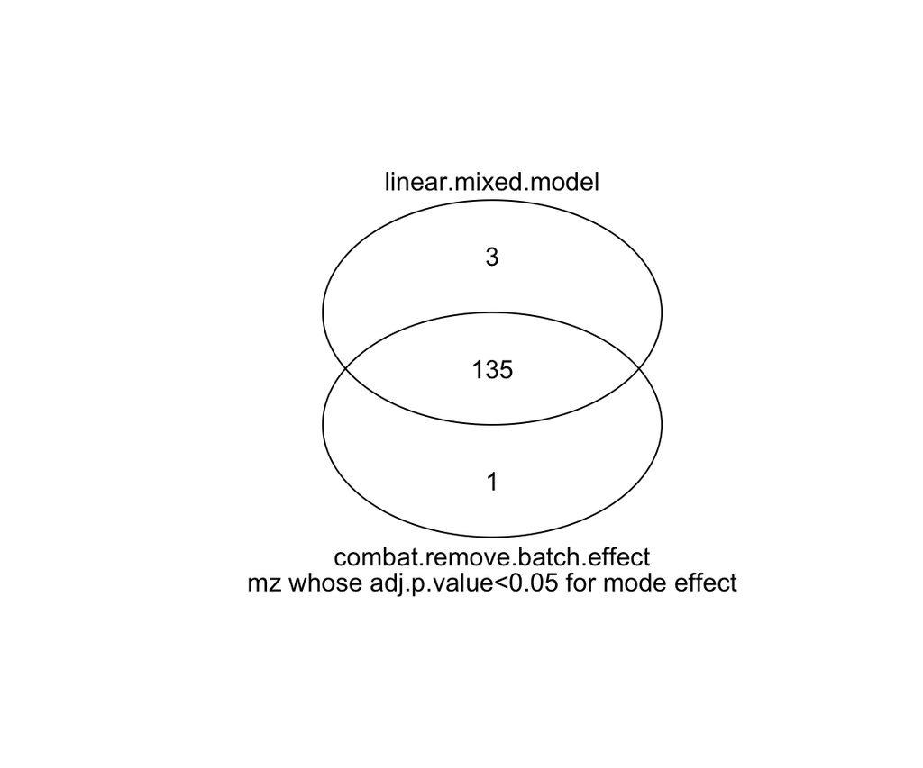

```r
library(gplots)
set1=rownames(df.sig.out.adj[df.sig.out.adj$mode<0.05,])
set2=rownames(df.sig.out.adj2[df.sig.out.adj2$mode<0.05,])
my.sets<-list('combat.remove.batch.effect'=set1,'linear.mixed.model'=set2)
venn(my.sets)
text(x=200,y=8,'mz whose adj.p.value<0.05 for mode effect')
```

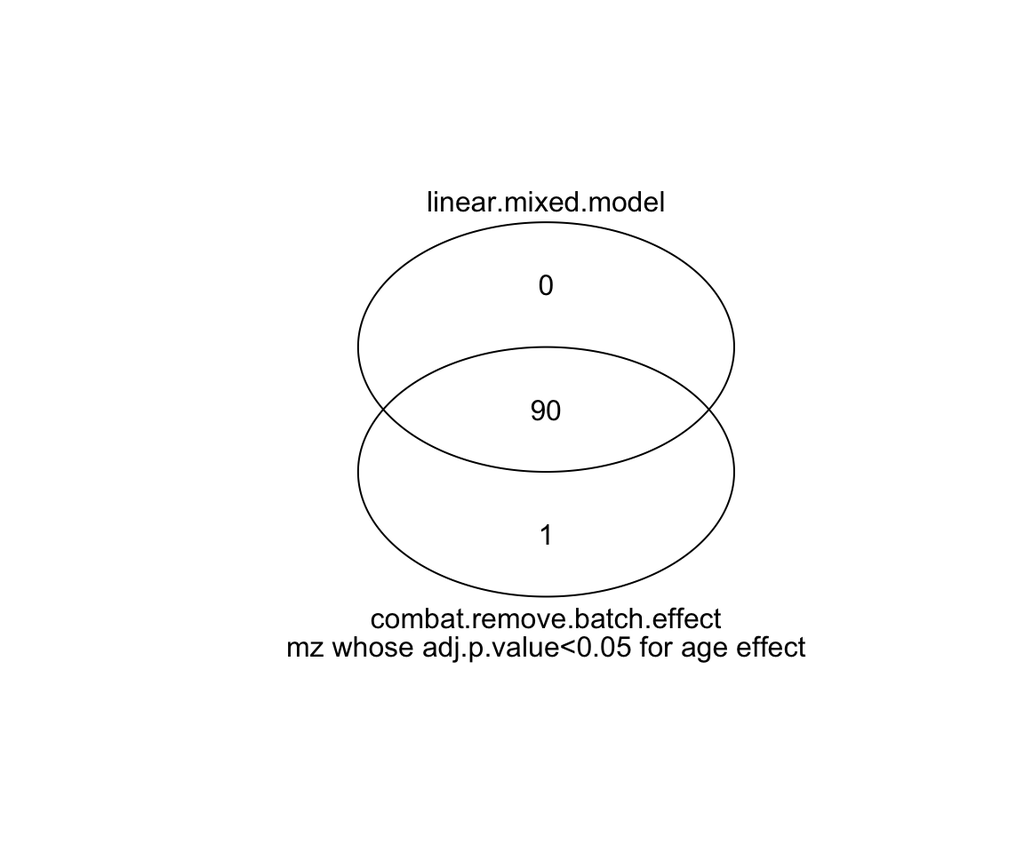

```r
set1=rownames(df.sig.out.adj[df.sig.out.adj$age<0.05,])
set2=rownames(df.sig.out.adj2[df.sig.out.adj2$age<0.05,])
my.sets<-list('combat.remove.batch.effect'=set1,'linear.mixed.model'=set2)
venn(my.sets)
text(x=200,y=8,'mz whose adj.p.value<0.05 for age effect')
```

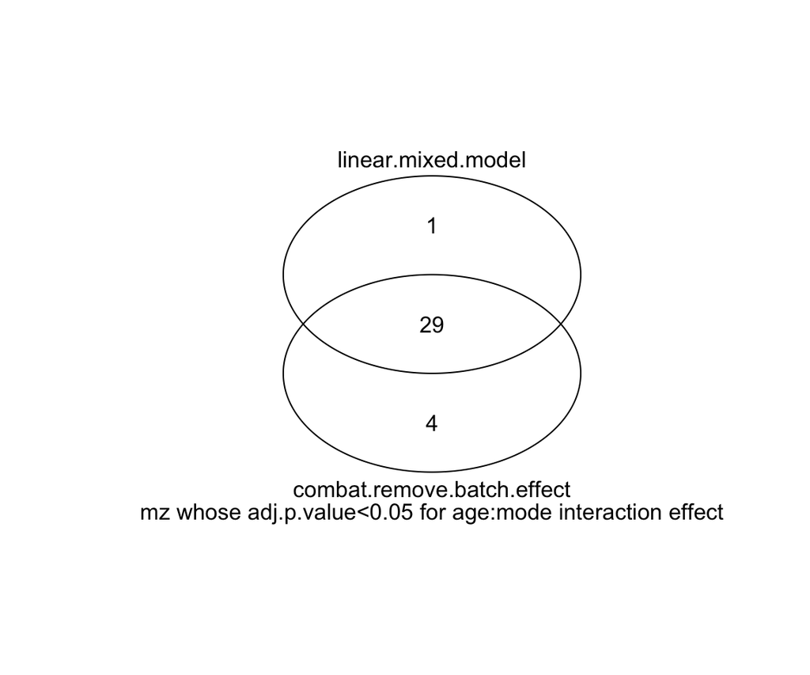

```r
set1=rownames(df.sig.out.adj[df.sig.out.adj$`age:mode`<0.05,])
set2=rownames(df.sig.out.adj2[df.sig.out.adj2$`age:mode`<0.05,])
my.sets<-list('combat.remove.batch.effect'=set1,'linear.mixed.model'=set2)
venn(my.sets)
text(x=200,y=8,'mz whose adj.p.value<0.05 for age:mode interaction effect')
```